# Risk Factor Analysis

## Outcome Variable

**Outcome Variable:** pers_wasted624

## Predictor Variables

**Intervention Variable:** pers_wasted06

**Adjustment Set:**

- sex
- arm
- enstunt
- month
- brthmon
- vagbrth
- single
- W_gagebrth
- W_birthwt
- W_birthlen
- W_mage
- W_mhtcm
- W_meducyrs
- W_feducyrs
- W_parity
- delta_month
- delta_brthmon
- delta_vagbrth
- delta_single
- delta_W_gagebrth
- delta_W_birthwt
- delta_W_birthlen
- delta_W_mage
- delta_W_mhtcm
- delta_W_meducyrs
- delta_W_feducyrs
- delta_W_parity

## Stratifying Variables

The analysis was stratified on these variable(s):

- studyid
- country

## Data Summary

| studyid | country | pers_wasted06 | pers_wasted624 | n_cell | n |
| --- | --- | --- | --- | --- | --- |
| ki0047075b-MAL-ED | BANGLADESH | 0 | 0 | 218 | 239 |
| ki0047075b-MAL-ED | BANGLADESH | 0 | 1 | 15 | 239 |
| ki0047075b-MAL-ED | BANGLADESH | 1 | 0 | 3 | 239 |
| ki0047075b-MAL-ED | BANGLADESH | 1 | 1 | 3 | 239 |
| ki0047075b-MAL-ED | BRAZIL | 0 | 0 | 200 | 202 |
| ki0047075b-MAL-ED | BRAZIL | 0 | 1 | 1 | 202 |
| ki0047075b-MAL-ED | BRAZIL | 1 | 0 | 0 | 202 |
| ki0047075b-MAL-ED | BRAZIL | 1 | 1 | 1 | 202 |
| ki0047075b-MAL-ED | INDIA | 0 | 0 | 198 | 234 |
| ki0047075b-MAL-ED | INDIA | 0 | 1 | 18 | 234 |
| ki0047075b-MAL-ED | INDIA | 1 | 0 | 8 | 234 |
| ki0047075b-MAL-ED | INDIA | 1 | 1 | 10 | 234 |
| ki0047075b-MAL-ED | NEPAL | 0 | 0 | 229 | 234 |
| ki0047075b-MAL-ED | NEPAL | 0 | 1 | 1 | 234 |
| ki0047075b-MAL-ED | NEPAL | 1 | 0 | 3 | 234 |
| ki0047075b-MAL-ED | NEPAL | 1 | 1 | 1 | 234 |
| ki0047075b-MAL-ED | PERU | 0 | 0 | 262 | 264 |
| ki0047075b-MAL-ED | PERU | 0 | 1 | 2 | 264 |
| ki0047075b-MAL-ED | PERU | 1 | 0 | 0 | 264 |
| ki0047075b-MAL-ED | PERU | 1 | 1 | 0 | 264 |
| ki0047075b-MAL-ED | SOUTH AFRICA | 0 | 0 | 255 | 258 |
| ki0047075b-MAL-ED | SOUTH AFRICA | 0 | 1 | 1 | 258 |
| ki0047075b-MAL-ED | SOUTH AFRICA | 1 | 0 | 1 | 258 |
| ki0047075b-MAL-ED | SOUTH AFRICA | 1 | 1 | 1 | 258 |
| ki0047075b-MAL-ED | TANZANIA, UNITED REPUBLIC OF | 0 | 0 | 244 | 244 |
| ki0047075b-MAL-ED | TANZANIA, UNITED REPUBLIC OF | 0 | 1 | 0 | 244 |
| ki0047075b-MAL-ED | TANZANIA, UNITED REPUBLIC OF | 1 | 0 | 0 | 244 |
| ki0047075b-MAL-ED | TANZANIA, UNITED REPUBLIC OF | 1 | 1 | 0 | 244 |
| ki1000108-CMC-V-BCS-2002 | INDIA | 0 | 0 | 302 | 368 |
| ki1000108-CMC-V-BCS-2002 | INDIA | 0 | 1 | 12 | 368 |

[output cut: 118 more lines]

The following strata were considered:

- studyid: ki0047075b-MAL-ED, country: BANGLADESH
- studyid: ki0047075b-MAL-ED, country: BRAZIL
- studyid: ki0047075b-MAL-ED, country: INDIA
- studyid: ki0047075b-MAL-ED, country: NEPAL
- studyid: ki0047075b-MAL-ED, country: PERU
- studyid: ki0047075b-MAL-ED, country: SOUTH AFRICA
- studyid: ki0047075b-MAL-ED, country: TANZANIA, UNITED REPUBLIC OF
- studyid: ki1000108-CMC-V-BCS-2002, country: INDIA
- studyid: ki1000108-IRC, country: INDIA
- studyid: ki1000109-EE, country: PAKISTAN
- studyid: ki1000109-ResPak, country: PAKISTAN
- studyid: ki1000304-VITAMIN-A, country: INDIA
- studyid: ki1000304b-SAS-CompFeed, country: INDIA
- studyid: ki1000304b-SAS-FoodSuppl, country: INDIA
- studyid: ki1017093-NIH-Birth, country: BANGLADESH
- studyid: ki1017093b-PROVIDE, country: BANGLADESH
- studyid: ki1017093c-NIH-Crypto, country: BANGLADESH
- studyid: ki1066203-TanzaniaChild2, country: TANZANIA, UNITED REPUBLIC OF
- studyid: ki1101329-Keneba, country: GAMBIA
- studyid: ki1112895-Burkina Faso Zn, country: BURKINA FASO
- studyid: ki1112895-Guatemala BSC, country: GUATEMALA
- studyid: ki1113344-GMS-Nepal, country: NEPAL
- studyid: ki1114097-CMIN, country: BANGLADESH
- studyid: ki1114097-CMIN, country: BRAZIL
- studyid: ki1114097-CMIN, country: GUINEA-BISSAU
- studyid: ki1114097-CMIN, country: PERU
- studyid: ki1114097-CONTENT, country: PERU
- studyid: ki1119695-PROBIT, country: BELARUS
- studyid: ki1126311-ZVITAMBO, country: ZIMBABWE
- studyid: ki1135781-COHORTS, country: GUATEMALA
- studyid: ki1135781-COHORTS, country: INDIA
- studyid: ki1135781-COHORTS, country: PHILIPPINES
- studyid: ki1148112-iLiNS-DOSE, country: MALAWI
- studyid: ki1148112-iLiNS-DYAD-M, country: MALAWI
- studyid: ki1148112-LCNI-5, country: MALAWI
- studyid: kiGH5241-JiVitA-3, country: BANGLADESH
- studyid: kiGH5241-JiVitA-4, country: BANGLADESH

### Dropped Strata

Some strata were dropped due to rare outcomes:

- studyid: ki0047075b-MAL-ED, country: BANGLADESH
- studyid: ki0047075b-MAL-ED, country: BRAZIL
- studyid: ki0047075b-MAL-ED, country: NEPAL
- studyid: ki0047075b-MAL-ED, country: PERU
- studyid: ki0047075b-MAL-ED, country: SOUTH AFRICA
- studyid: ki0047075b-MAL-ED, country: TANZANIA, UNITED REPUBLIC OF
- studyid: ki1017093c-NIH-Crypto, country: BANGLADESH
- studyid: ki1112895-Burkina Faso Zn, country: BURKINA FASO
- studyid: ki1112895-Guatemala BSC, country: GUATEMALA
- studyid: ki1114097-CMIN, country: BANGLADESH
- studyid: ki1114097-CMIN, country: BRAZIL
- studyid: ki1114097-CMIN, country: PERU
- studyid: ki1114097-CONTENT, country: PERU
- studyid: ki1148112-iLiNS-DOSE, country: MALAWI
- studyid: ki1148112-iLiNS-DYAD-M, country: MALAWI
- studyid: ki1148112-LCNI-5, country: MALAWI

## Methods Detail

We’re interested in the causal parameters $E[Y_a]$ for all values of $a \in \mathcal{A}$. These parameters represent the mean outcome if, possibly contrary to fact, we intervened to set all units to have $A=a$. Under the randomization and positivity assumptions, these are identified by the statistical parameters $\psi_a=E_W[E_{Y|A,W}(Y|A=a,W)]$. In addition, we’re interested in the mean of $Y$, $E[Y]$ under no intervention (the observed mean). We will estimate these parameters by using SuperLearner to fit the relevant likelihood factors – $E_{Y|A,W}(Y|A=a,W)$ and $p(A=a|W)$, and then updating our likelihood fit using a joint TMLE.

For unadjusted analyses ($W=\{\}$), initial likelihoods were estimated using Lrnr_glm to estimate the simple $E(Y|A)$ and Lrnr_mean to estimate $p(A)$. For adjusted analyses, a small library containing Lrnr_glmnet, Lrnr_xgboost, and Lrnr_mean was used.

Having estimated these parameters, we will then use the delta method to estimate relative risks and attributable risks relative to a prespecified baseline level of $A$.

# Results Detail

## Results Plots

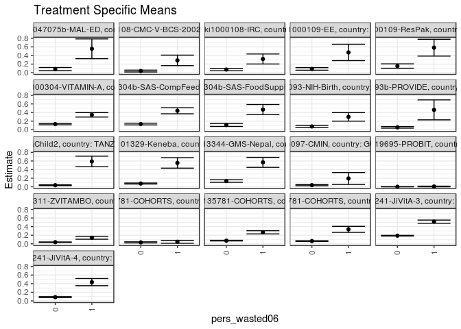

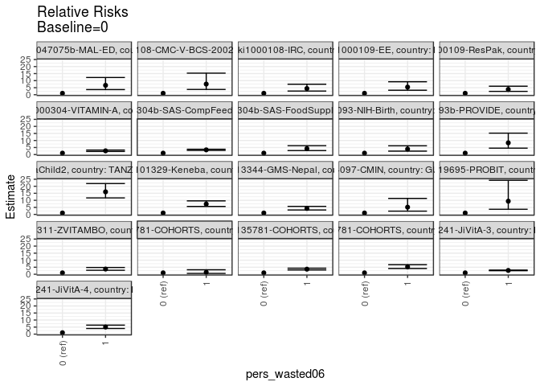

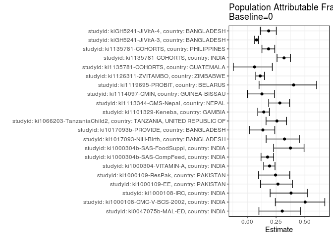

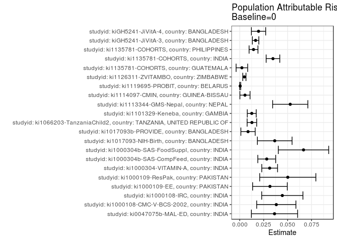

## Results Table

### Parameter: TSM

| studyid | country | intervention_level | baseline_level | estimate | ci_lower | ci_upper |
| --- | --- | --- | --- | --- | --- | --- |
| ki0047075b-MAL-ED | INDIA | 0 | NA | 0.0833333 | 0.0463959 | 0.1202707 |
| ki0047075b-MAL-ED | INDIA | 1 | NA | 0.5555556 | 0.3255098 | 0.7856013 |
| ki1000108-CMC-V-BCS-2002 | INDIA | 0 | NA | 0.0378927 | 0.0166344 | 0.0591510 |
| ki1000108-CMC-V-BCS-2002 | INDIA | 1 | NA | 0.2862220 | 0.1638761 | 0.4085678 |
| ki1000108-IRC | INDIA | 0 | NA | 0.0725923 | 0.0449867 | 0.1001979 |
| ki1000108-IRC | INDIA | 1 | NA | 0.3186026 | 0.2022498 | 0.4349554 |
| ki1000109-EE | PAKISTAN | 0 | NA | 0.0870322 | 0.0571085 | 0.1169559 |
| ki1000109-EE | PAKISTAN | 1 | NA | 0.4709333 | 0.2801222 | 0.6617444 |
| ki1000109-ResPak | PAKISTAN | 0 | NA | 0.1543708 | 0.1034124 | 0.2053292 |
| ki1000109-ResPak | PAKISTAN | 1 | NA | 0.5819594 | 0.3862128 | 0.7777060 |
| ki1000304-VITAMIN-A | INDIA | 0 | NA | 0.1304785 | 0.1156183 | 0.1453388 |
| ki1000304-VITAMIN-A | INDIA | 1 | NA | 0.3467420 | 0.2947700 | 0.3987140 |
| ki1000304b-SAS-CompFeed | INDIA | 0 | NA | 0.1321442 | 0.1123855 | 0.1519029 |
| ki1000304b-SAS-CompFeed | INDIA | 1 | NA | 0.4412594 | 0.3705268 | 0.5119919 |
| ki1000304b-SAS-FoodSuppl | INDIA | 0 | NA | 0.1112265 | 0.0766275 | 0.1458255 |
| ki1000304b-SAS-FoodSuppl | INDIA | 1 | NA | 0.4687735 | 0.3510988 | 0.5864481 |
| ki1017093-NIH-Birth | BANGLADESH | 0 | NA | 0.0767175 | 0.0515031 | 0.1019320 |
| ki1017093-NIH-Birth | BANGLADESH | 1 | NA | 0.2986937 | 0.1991747 | 0.3982127 |
| ki1017093b-PROVIDE | BANGLADESH | 0 | NA | 0.0554622 | 0.0369881 | 0.0739363 |
| ki1017093b-PROVIDE | BANGLADESH | 1 | NA | 0.4615385 | 0.2295775 | 0.6934994 |
| ki1066203-TanzaniaChild2 | TANZANIA, UNITED REPUBLIC OF | 0 | NA | 0.0367356 | 0.0281891 | 0.0452821 |
| ki1066203-TanzaniaChild2 | TANZANIA, UNITED REPUBLIC OF | 1 | NA | 0.5890830 | 0.4656621 | 0.7125040 |
| ki1101329-Keneba | GAMBIA | 0 | NA | 0.0753473 | 0.0641062 | 0.0865884 |
| ki1101329-Keneba | GAMBIA | 1 | NA | 0.5551012 | 0.4333294 | 0.6768731 |
| ki1113344-GMS-Nepal | NEPAL | 0 | NA | 0.1339084 | 0.1044604 | 0.1633565 |
| ki1113344-GMS-Nepal | NEPAL | 1 | NA | 0.5680635 | 0.4521144 | 0.6840126 |
| ki1114097-CMIN | GUINEA-BISSAU | 0 | NA | 0.0377358 | 0.0249030 | 0.0505687 |
| ki1114097-CMIN | GUINEA-BISSAU | 1 | NA | 0.1935484 | 0.0543935 | 0.3327032 |
| ki1119695-PROBIT | BELARUS | 0 | NA | 0.0007270 | 0.0001693 | 0.0012847 |
| ki1119695-PROBIT | BELARUS | 1 | NA | 0.0068285 | -0.0005804 | 0.0142374 |
| ki1126311-ZVITAMBO | ZIMBABWE | 0 | NA | 0.0383618 | 0.0341784 | 0.0425452 |
| ki1126311-ZVITAMBO | ZIMBABWE | 1 | NA | 0.1417193 | 0.1073730 | 0.1760656 |
| ki1135781-COHORTS | GUATEMALA | 0 | NA | 0.0334225 | 0.0205347 | 0.0463102 |
| ki1135781-COHORTS | GUATEMALA | 1 | NA | 0.0469799 | 0.0129857 | 0.0809740 |
| ki1135781-COHORTS | INDIA | 0 | NA | 0.0740664 | 0.0662669 | 0.0818660 |
| ki1135781-COHORTS | INDIA | 1 | NA | 0.2679840 | 0.2312864 | 0.3046816 |
| ki1135781-COHORTS | PHILIPPINES | 0 | NA | 0.0636016 | 0.0541975 | 0.0730057 |
| ki1135781-COHORTS | PHILIPPINES | 1 | NA | 0.3363687 | 0.2666164 | 0.4061211 |
| kiGH5241-JiVitA-3 | BANGLADESH | 0 | NA | 0.1890809 | 0.1812526 | 0.1969092 |
| kiGH5241-JiVitA-3 | BANGLADESH | 1 | NA | 0.5155899 | 0.4790689 | 0.5521110 |
| kiGH5241-JiVitA-4 | BANGLADESH | 0 | NA | 0.0862214 | 0.0744428 | 0.0979999 |
| kiGH5241-JiVitA-4 | BANGLADESH | 1 | NA | 0.4354467 | 0.3525362 | 0.5183572 |

### Parameter: E(Y)

| studyid | country | intervention_level | baseline_level | estimate | ci_lower | ci_upper |
| --- | --- | --- | --- | --- | --- | --- |
| ki0047075b-MAL-ED | INDIA | NA | NA | 0.1196581 | 0.0779840 | 0.1613323 |
| ki1000108-CMC-V-BCS-2002 | INDIA | NA | NA | 0.0760870 | 0.0489610 | 0.1032130 |
| ki1000108-IRC | INDIA | NA | NA | 0.1170732 | 0.0859146 | 0.1482317 |
| ki1000109-EE | PAKISTAN | NA | NA | 0.1185984 | 0.0856546 | 0.1515422 |
| ki1000109-ResPak | PAKISTAN | NA | NA | 0.2045455 | 0.1511224 | 0.2579685 |
| ki1000304-VITAMIN-A | INDIA | NA | NA | 0.1617391 | 0.1466878 | 0.1767905 |
| ki1000304b-SAS-CompFeed | INDIA | NA | NA | 0.1603563 | 0.1395035 | 0.1812092 |
| ki1000304b-SAS-FoodSuppl | INDIA | NA | NA | 0.1778351 | 0.1397389 | 0.2159312 |
| ki1017093-NIH-Birth | BANGLADESH | NA | NA | 0.1132813 | 0.0858017 | 0.1407608 |
| ki1017093b-PROVIDE | BANGLADESH | NA | NA | 0.0641447 | 0.0446535 | 0.0836359 |
| ki1066203-TanzaniaChild2 | TANZANIA, UNITED REPUBLIC OF | NA | NA | 0.0494534 | 0.0397554 | 0.0591514 |
| ki1101329-Keneba | GAMBIA | NA | NA | 0.0879121 | 0.0760335 | 0.0997906 |
| ki1113344-GMS-Nepal | NEPAL | NA | NA | 0.1866438 | 0.1550166 | 0.2182711 |
| ki1114097-CMIN | GUINEA-BISSAU | NA | NA | 0.0432309 | 0.0297785 | 0.0566834 |
| ki1119695-PROBIT | BELARUS | NA | NA | 0.0012159 | 0.0002433 | 0.0021885 |
| ki1126311-ZVITAMBO | ZIMBABWE | NA | NA | 0.0432128 | 0.0388939 | 0.0475316 |
| ki1135781-COHORTS | GUATEMALA | NA | NA | 0.0356745 | 0.0235298 | 0.0478191 |
| ki1135781-COHORTS | INDIA | NA | NA | 0.1087695 | 0.1008135 | 0.1167256 |
| ki1135781-COHORTS | PHILIPPINES | NA | NA | 0.0780116 | 0.0679971 | 0.0880261 |
| kiGH5241-JiVitA-3 | BANGLADESH | NA | NA | 0.2056528 | 0.1980793 | 0.2132263 |
| kiGH5241-JiVitA-4 | BANGLADESH | NA | NA | 0.1058706 | 0.0951082 | 0.1166330 |

### Parameter: RR

| studyid | country | intervention_level | baseline_level | estimate | ci_lower | ci_upper |
| --- | --- | --- | --- | --- | --- | --- |
| ki0047075b-MAL-ED | INDIA | 0 | 0 | 1.000000 | 1.0000000 | 1.000000 |
| ki0047075b-MAL-ED | INDIA | 1 | 0 | 6.666667 | 3.6347655 | 12.227596 |
| ki1000108-CMC-V-BCS-2002 | INDIA | 0 | 0 | 1.000000 | 1.0000000 | 1.000000 |
| ki1000108-CMC-V-BCS-2002 | INDIA | 1 | 0 | 7.553486 | 3.7271573 | 15.307952 |
| ki1000108-IRC | INDIA | 0 | 0 | 1.000000 | 1.0000000 | 1.000000 |
| ki1000108-IRC | INDIA | 1 | 0 | 4.388933 | 2.5874788 | 7.444594 |
| ki1000109-EE | PAKISTAN | 0 | 0 | 1.000000 | 1.0000000 | 1.000000 |
| ki1000109-EE | PAKISTAN | 1 | 0 | 5.411025 | 3.1822638 | 9.200744 |
| ki1000109-ResPak | PAKISTAN | 0 | 0 | 1.000000 | 1.0000000 | 1.000000 |
| ki1000109-ResPak | PAKISTAN | 1 | 0 | 3.769880 | 2.3566389 | 6.030621 |
| ki1000304-VITAMIN-A | INDIA | 0 | 0 | 1.000000 | 1.0000000 | 1.000000 |
| ki1000304-VITAMIN-A | INDIA | 1 | 0 | 2.657464 | 2.2028574 | 3.205889 |
| ki1000304b-SAS-CompFeed | INDIA | 0 | 0 | 1.000000 | 1.0000000 | 1.000000 |
| ki1000304b-SAS-CompFeed | INDIA | 1 | 0 | 3.339227 | 2.9639571 | 3.762011 |
| ki1000304b-SAS-FoodSuppl | INDIA | 0 | 0 | 1.000000 | 1.0000000 | 1.000000 |
| ki1000304b-SAS-FoodSuppl | INDIA | 1 | 0 | 4.214585 | 2.8243311 | 6.289179 |
| ki1017093-NIH-Birth | BANGLADESH | 0 | 0 | 1.000000 | 1.0000000 | 1.000000 |
| ki1017093-NIH-Birth | BANGLADESH | 1 | 0 | 3.893422 | 2.4331774 | 6.230015 |
| ki1017093b-PROVIDE | BANGLADESH | 0 | 0 | 1.000000 | 1.0000000 | 1.000000 |
| ki1017093b-PROVIDE | BANGLADESH | 1 | 0 | 8.321678 | 4.5536120 | 15.207780 |
| ki1066203-TanzaniaChild2 | TANZANIA, UNITED REPUBLIC OF | 0 | 0 | 1.000000 | 1.0000000 | 1.000000 |
| ki1066203-TanzaniaChild2 | TANZANIA, UNITED REPUBLIC OF | 1 | 0 | 16.035760 | 11.7248045 | 21.931761 |
| ki1101329-Keneba | GAMBIA | 0 | 0 | 1.000000 | 1.0000000 | 1.000000 |
| ki1101329-Keneba | GAMBIA | 1 | 0 | 7.367233 | 5.6503719 | 9.605762 |
| ki1113344-GMS-Nepal | NEPAL | 0 | 0 | 1.000000 | 1.0000000 | 1.000000 |
| ki1113344-GMS-Nepal | NEPAL | 1 | 0 | 4.242179 | 3.1481771 | 5.716350 |
| ki1114097-CMIN | GUINEA-BISSAU | 0 | 0 | 1.000000 | 1.0000000 | 1.000000 |
| ki1114097-CMIN | GUINEA-BISSAU | 1 | 0 | 5.129032 | 2.3153952 | 11.361763 |
| ki1119695-PROBIT | BELARUS | 0 | 0 | 1.000000 | 1.0000000 | 1.000000 |
| ki1119695-PROBIT | BELARUS | 1 | 0 | 9.392951 | 3.6435746 | 24.214551 |
| ki1126311-ZVITAMBO | ZIMBABWE | 0 | 0 | 1.000000 | 1.0000000 | 1.000000 |
| ki1126311-ZVITAMBO | ZIMBABWE | 1 | 0 | 3.694281 | 2.8323981 | 4.818429 |
| ki1135781-COHORTS | GUATEMALA | 0 | 0 | 1.000000 | 1.0000000 | 1.000000 |
| ki1135781-COHORTS | GUATEMALA | 1 | 0 | 1.405638 | 0.6191362 | 3.191248 |
| ki1135781-COHORTS | INDIA | 0 | 0 | 1.000000 | 1.0000000 | 1.000000 |
| ki1135781-COHORTS | INDIA | 1 | 0 | 3.618157 | 3.0468288 | 4.296618 |
| ki1135781-COHORTS | PHILIPPINES | 0 | 0 | 1.000000 | 1.0000000 | 1.000000 |
| ki1135781-COHORTS | PHILIPPINES | 1 | 0 | 5.288683 | 4.1041038 | 6.815172 |
| kiGH5241-JiVitA-3 | BANGLADESH | 0 | 0 | 1.000000 | 1.0000000 | 1.000000 |
| kiGH5241-JiVitA-3 | BANGLADESH | 1 | 0 | 2.726822 | 2.5139566 | 2.957711 |
| kiGH5241-JiVitA-4 | BANGLADESH | 0 | 0 | 1.000000 | 1.0000000 | 1.000000 |
| kiGH5241-JiVitA-4 | BANGLADESH | 1 | 0 | 5.050334 | 3.9927570 | 6.388037 |

### Parameter: PAR

| studyid | country | intervention_level | baseline_level | estimate | ci_lower | ci_upper |
| --- | --- | --- | --- | --- | --- | --- |
| ki0047075b-MAL-ED | INDIA | 0 | NA | 0.0363248 | 0.0121946 | 0.0604550 |
| ki1000108-CMC-V-BCS-2002 | INDIA | 0 | NA | 0.0381943 | 0.0177129 | 0.0586756 |
| ki1000108-IRC | INDIA | 0 | NA | 0.0444809 | 0.0229551 | 0.0660067 |
| ki1000109-EE | PAKISTAN | 0 | NA | 0.0315662 | 0.0134623 | 0.0496701 |
| ki1000109-ResPak | PAKISTAN | 0 | NA | 0.0501747 | 0.0208629 | 0.0794864 |
| ki1000304-VITAMIN-A | INDIA | 0 | NA | 0.0312606 | 0.0230161 | 0.0395051 |
| ki1000304b-SAS-CompFeed | INDIA | 0 | NA | 0.0282122 | 0.0188785 | 0.0375459 |
| ki1000304b-SAS-FoodSuppl | INDIA | 0 | NA | 0.0666086 | 0.0403070 | 0.0929101 |
| ki1017093-NIH-Birth | BANGLADESH | 0 | NA | 0.0365637 | 0.0184583 | 0.0546691 |
| ki1017093b-PROVIDE | BANGLADESH | 0 | NA | 0.0086826 | 0.0012208 | 0.0161443 |
| ki1066203-TanzaniaChild2 | TANZANIA, UNITED REPUBLIC OF | 0 | NA | 0.0127178 | 0.0077306 | 0.0177050 |
| ki1101329-Keneba | GAMBIA | 0 | NA | 0.0125648 | 0.0078942 | 0.0172354 |
| ki1113344-GMS-Nepal | NEPAL | 0 | NA | 0.0527354 | 0.0343573 | 0.0711135 |
| ki1114097-CMIN | GUINEA-BISSAU | 0 | NA | 0.0054951 | 0.0002127 | 0.0107775 |
| ki1119695-PROBIT | BELARUS | 0 | NA | 0.0004889 | -0.0000743 | 0.0010521 |
| ki1126311-ZVITAMBO | ZIMBABWE | 0 | NA | 0.0048510 | 0.0031639 | 0.0065380 |
| ki1135781-COHORTS | GUATEMALA | 0 | NA | 0.0022520 | -0.0037959 | 0.0083000 |
| ki1135781-COHORTS | INDIA | 0 | NA | 0.0347031 | 0.0275774 | 0.0418289 |
| ki1135781-COHORTS | PHILIPPINES | 0 | NA | 0.0144100 | 0.0097684 | 0.0190516 |
| kiGH5241-JiVitA-3 | BANGLADESH | 0 | NA | 0.0165719 | 0.0131929 | 0.0199509 |
| kiGH5241-JiVitA-4 | BANGLADESH | 0 | NA | 0.0196493 | 0.0121985 | 0.0271001 |

### Parameter: PAF

| studyid | country | intervention_level | baseline_level | estimate | ci_lower | ci_upper |
| --- | --- | --- | --- | --- | --- | --- |
| ki0047075b-MAL-ED | INDIA | 0 | NA | 0.3035714 | 0.1010431 | 0.4604716 |
| ki1000108-CMC-V-BCS-2002 | INDIA | 0 | NA | 0.5019816 | 0.2429616 | 0.6723782 |
| ki1000108-IRC | INDIA | 0 | NA | 0.3799409 | 0.1982126 | 0.5204798 |
| ki1000109-EE | PAKISTAN | 0 | NA | 0.2661606 | 0.1146425 | 0.3917482 |
| ki1000109-ResPak | PAKISTAN | 0 | NA | 0.2452983 | 0.0980502 | 0.3685074 |
| ki1000304-VITAMIN-A | INDIA | 0 | NA | 0.1932780 | 0.1430154 | 0.2405926 |
| ki1000304b-SAS-CompFeed | INDIA | 0 | NA | 0.1759343 | 0.1191907 | 0.2290224 |
| ki1000304b-SAS-FoodSuppl | INDIA | 0 | NA | 0.3745525 | 0.2290719 | 0.4925797 |
| ki1017093-NIH-Birth | BANGLADESH | 0 | NA | 0.3227693 | 0.1636418 | 0.4516208 |
| ki1017093b-PROVIDE | BANGLADESH | 0 | NA | 0.1353588 | 0.0179429 | 0.2387362 |
| ki1066203-TanzaniaChild2 | TANZANIA, UNITED REPUBLIC OF | 0 | NA | 0.2571678 | 0.1628208 | 0.3408822 |
| ki1101329-Keneba | GAMBIA | 0 | NA | 0.1429243 | 0.0912300 | 0.1916781 |
| ki1113344-GMS-Nepal | NEPAL | 0 | NA | 0.2825457 | 0.1862236 | 0.3674667 |
| ki1114097-CMIN | GUINEA-BISSAU | 0 | NA | 0.1271102 | 0.0028857 | 0.2358584 |
| ki1119695-PROBIT | BELARUS | 0 | NA | 0.4020917 | 0.1022350 | 0.6017952 |
| ki1126311-ZVITAMBO | ZIMBABWE | 0 | NA | 0.1122578 | 0.0739072 | 0.1490204 |
| ki1135781-COHORTS | GUATEMALA | 0 | NA | 0.0631267 | -0.1211887 | 0.2171419 |
| ki1135781-COHORTS | INDIA | 0 | NA | 0.3190517 | 0.2581665 | 0.3749398 |
| ki1135781-COHORTS | PHILIPPINES | 0 | NA | 0.1847162 | 0.1272021 | 0.2384404 |
| kiGH5241-JiVitA-3 | BANGLADESH | 0 | NA | 0.0805820 | 0.0641740 | 0.0967023 |
| kiGH5241-JiVitA-4 | BANGLADESH | 0 | NA | 0.1855971 | 0.1135279 | 0.2518072 |